# Codify Vault Enterprise management with Terraform

- 20min
- |
- Enterprise
- Terraform
- Vault

## Personas

The scenario described in this tutorial introduces the following personas:

- **`admin`** is the organization-level administrator
- **`student`** is a user allowed to write data to a path in vault

## Challenge

A manual system administration can become a challenge as the scale of infrastructure increases. Often, an organization must manage multiple Vault environments (development, testing, staging, production, etc.). Keeping up with the increasing management demand soon becomes a challenge without some sort of automation.

## Solution

One of the pillars behind the [Tao of HashiCorp](https://www.hashicorp.com/tao-of-hashicorp) is *automation through codification*.

HashiCorp Terraform is an **infrastructure as code** which enables the operation team to codify the Vault configuration tasks such as the creation of policies. Automation through codification allows operators to increase their productivity, move quicker, promote **repeatable** processes, and reduce human error.

This tutorial demonstrates techniques for creating Vault policies and configurations using [Terraform Vault provider](https://registry.terraform.io/providers/hashicorp/vault/latest/docs).

## Prerequisites

- Terraform
- [Vault CLI](https://developer.hashicorp.com/vault/tutorials/get-started/install-binary)
- [Vault Enterprise](https://developer.hashicorp.com/nomad/tutorials/enterprise/hashicorp-enterprise-license)
- [Vault CLI](https://developer.hashicorp.com/vault/tutorials/get-started/install-binary)
- [Vault Enterprise](https://developer.hashicorp.com/nomad/tutorials/enterprise/hashicorp-enterprise-license)
- [Docker](https://docs.docker.com/get-docker/)

Enterprise Only

This tutorial creates namespaces which require [Vault Enterprise Standard](https://www.hashicorp.com/products/vault/pricing/) license.

If you are running Vault Community, see the [Learn to use the Vault Terraform provider](https://developer.hashicorp.com/vault/tutorials/get-started/learn-terraform) tutorial.

## Scenario introduction

Vault administrators must manage multiple Vault environments. The test servers Vault administrators, at the end of each test cycle destroy the test servers and provision a new set of servers for the next test cycle. To automate the Vault server configuration, you are going to use Terraform to provision the following Vault resources.

[output not shown]

You need to create the `admins` policy in all namespaces: `root`, `finance`, and `engineering`. The expected admin tasks are the same across the namespaces.

Note

Transform secrets engine requires [Vault Enterprise Advanced Data Protection (ADP)](https://www.hashicorp.com/products/vault/pricing/) license.

## Examine the Terraform files

1. Clone or download the demo assets from the [hashicorp/learn-vault-codify](https://github.com/hashicorp-education/learn-vault-codify) GitHub repository to perform the steps described in this tutorial.

   ```
   $ git clone https://github.com/hashicorp-education/learn-vault-codify
   ```

2. Change the working directory to `learn-vault-codify/enterprise`.

   ```
   $ cd learn-vault-codify/enterprise
   ```

   The directory contains Terraform files to configure Vault.

   ```
   .
   ├── auth.tf
   ├── main.tf
   ├── policies
   │   ├── admin-policy.hcl
   │   └── fpe-client-policy.hcl
   ├── policies.tf
   ├── provider.tf
   ├── secrets.tf
   ```

### Review provider.tf

Open the `provider.tf` file in your preferred text editor to examine its content.

provider.tf

```
# Copyright IBM Corp. 2018, 2026
# SPDX-License-Identifier: MPL-2.0

#------------------------------------------------------------------------------
# To configure Transform secrets engine, you need vault provider v2.12.0 or later
#------------------------------------------------------------------------------
terraform {
  required_providers {
    vault = {
      source  = "hashicorp/vault"
      version = "~> 5.0.0"
    }
  }
}
#------------------------------------------------------------------------------
# To leverage more than one namespace, define a vault provider per namespace
#------------------------------------------------------------------------------

provider "vault" {
   # configuration options
}
```

Each Terraform module must declare which providers it requires, so that Terraform can install and use them. The `required_providers` block declares the provider requirements

The `terraform` block in the `provider.tf` file declares that this module requires the `vault` provider. The `source` argument specifies the provider's source address, which is `hashicorp/vault`. The `version` argument specifies the version of the provider to use.

The `provider` block for `vault` instructs Terraform to interact with the Vault API and requires a `address` and `token`. Terraform looks for the `VAULT_ADDR` and `VAULT_TOKEN` environment variables to set these. See [Vault Terraform provider documentation](https://registry.terraform.io/providers/hashicorp/vault/latest/docs#provider-arguments) for more information.

### Review main.tf

Open the `main.tf` file in your preferred text editor to examine its content.

main.tf

```
#------------------------------------------------------------------------------
# Create namespaces: finance, and engineering
#------------------------------------------------------------------------------
resource "vault_namespace" "finance" {
  path = "finance"
}

resource "vault_namespace" "engineering" {
  path = "engineering"
}

#---------------------------------------------------------------
# Create nested namespaces
#   education has childnamespace, 'training'
#       training has childnamespace, 'secure'
#           secure has childnamespace, 'vault_cloud' and 'boundary'
#---------------------------------------------------------------
resource "vault_namespace" "education" {
  path = "education"
}


# Create a childnamespace, 'training' under 'education'
resource "vault_namespace" "training" {
  namespace = vault_namespace.education.path
  path = "training"
}

# Create a childnamespace, 'vault_cloud' and 'boundary' under 'education/training'
resource "vault_namespace" "vault_cloud" {
  namespace = vault_namespace.training.path_fq
  path = "vault_cloud"
}

# Create 'education/training/boundary' namespace
resource "vault_namespace" "boundary" {
  namespace = vault_namespace.training.path_fq
  path = "boundary"
}

# create a kv v2 secrets engine in the root namespace
resource "vault_mount" "kvv2" {
  path        = "my-kvv2"
  type        = "kv"
  options     = { version = "2" }
}

# Create a kv v2 secrets with the data_json_wo argument
resource "vault_kv_secret_v2" "db_root" {
  mount                      = vault_mount.kvv2.path
  name                       = "pgx-root"
  data_json_wo                  = jsonencode(
    {
      password       = "root-user-password"
    }
  )
  data_json_wo_version = 1
}

# create an ephemeral vault_kv_secret_v2 resource
ephemeral "vault_kv_secret_v2" "db_secret" {
  mount = vault_mount.kvv2.path
  mount_id = vault_mount.kvv2.id
  name = vault_kv_secret_v2.db_root.name
}

# mount a database secrets engine at the path "postgres"
resource "vault_mount" "db" {
  path = "postgres"
  type = "database"
}

# create a database role for the postgres database with a
# PostgreSQL Configuration Option password_wo
resource "vault_database_secret_backend_connection" "postgres" {
  backend       = vault_mount.db.path
  name          = "learn-postrgres"
  allowed_roles = ["*"]

  postgresql {
    connection_url = "postgresql://{{username}}:{{password}}@localhost:5432/postgres?sslmode=disable"
    password_authentication = ""
    username = "postgres"
    password_wo = tostring(ephemeral.vault_kv_secret_v2.db_secret.data.password)
    password_wo_version = 1
  }
}
```

To create a `education/training` namespace, use the `namespace` parameter to point the `vault_namespace.education.path` parent namespace.

```
resource "vault_namespace" "training" {
  namespace = vault_namespace.education.path
  path = "training"
}
```

Recomendation

It is strongly recommended to specify the [target server specific information](https://registry.terraform.io/providers/hashicorp/vault/latest/docs#provider-arguments) using environment variables (e.g. `VAULT_ADDR`, `VAULT_TOKEN`); that is what you are going to do in this tutorial.

Note

If you are not familiar with Vault Enterprise namespace, refer to the [Secure Multi-Tenancy with Namespaces](https://developer.hashicorp.com/vault/tutorials/enterprise/namespaces) tutorial.

In this example, we use the an ephemeral resource to set the root credential password for the PostgreSQL database.

Ephemeral resources create a temporary resource that is not persisted in Terraform state file or plan files. The user can access the data in their configurations but the information is not stored. Each `ephemeral` block describes a resource, such as a temporary password.

[Vault provider version 5.0.0](https://registry.terraform.io/providers/hashicorp/vault/latest/docs/guides/using_ephemeral_resources) and later supports the `ephemeral` block. The `vault_kv_secret_v2` resource creates a secret in the `kv-v2` secrets engine. The `data_json_wo` argument specifies the secret data should be write only. It will not be written to the state file or displayed in the plan. The `postgressql.password_wo` argument in the `vault_database_secret_backend_connection` resource will use the ephemeral resource to set the password for the PostgreSQL database.

```
# create an ephemeral vault_kv_secret_v2 resource
ephemeral "vault_kv_secret_v2" "db_secret" {
  mount = vault_mount.kvv2.path
  mount_id = vault_mount.kvv2.id
  name = vault_kv_secret_v2.db_root.name
}
```

### Review policies.tf

policies.tf

```
# Copyright IBM Corp. 2018, 2026
# SPDX-License-Identifier: MPL-2.0

#---------------------
# Create policies
#---------------------
# Create fpe-client policy in the root namespace
resource "vault_policy" "fpe_client_policy" {
  name   = "fpe-client"
  policy = file("policies/fpe-client-policy.hcl")
}

# Create admin policy in the root namespace
resource "vault_policy" "admin_policy" {
  name   = "admins"
  policy = file("policies/admin-policy.hcl")
}

# Create admin policy in the finance namespace
resource "vault_policy" "admin_policy_finance" {
  namespace = vault_namespace.finance.path
  name   = "admins"
  policy = file("policies/admin-policy.hcl")
}

# Create admin policy in the engineering namespace
resource "vault_policy" "admin_policy_engineering" {
  namespace = vault_namespace.engineering.path
  name   = "admins"
  policy = file("policies/admin-policy.hcl")
}

# Create admin policy in the education namespace
resource "vault_policy" "admin_policy_education" {
  namespace = vault_namespace.education.path
  name   = "admins"
  policy = file("policies/admin-policy.hcl")
}

# Create admin policy in the 'education/training' namespace
resource "vault_policy" "admin_policy_training" {
  namespace = vault_namespace.training.path_fq
  name   = "admins"
  policy = file("policies/admin-policy.hcl")
}

# Create admin policy in the 'education/training/vault_cloud' namespace
resource "vault_policy" "admin_policy_vault_cloud" {
  namespace = vault_namespace.vault_cloud.path_fq
  name   = "admins"
  policy = file("policies/admin-policy.hcl")
}

# Create admin policy in the 'education/training/boundary' namespace
resource "vault_policy" "admin_policy_boundary" {
  namespace = vault_namespace.boundary.path_fq
  name   = "admins"
  policy = file("policies/admin-policy.hcl")
}
```

### Review auth.tf

Open the `auth.tf` file.

auth.tf

```
# Copyright IBM Corp. 2018, 2026
# SPDX-License-Identifier: MPL-2.0

#--------------------------------
# Enable userpass auth method
#--------------------------------
resource "vault_auth_backend" "userpass" {
  type = "userpass"
}

# Create a user named, "student"
resource "vault_generic_endpoint" "student" {
  depends_on           = [vault_auth_backend.userpass]
  path                 = "auth/userpass/users/student"
  ignore_absent_fields = true

  data_json = <<EOT
{
  "policies": ["fpe-client", "admins"],
  "password": "changeme"
}
EOT
}

#--------------------------------------------------------------------
# Enable approle auth method in the 'education/training' namespace
#--------------------------------------------------------------------
resource "vault_auth_backend" "approle" {
  depends_on = [vault_namespace.training]
  namespace = vault_namespace.training.path_fq
  type       = "approle"
}

# Create a role named, "test-role"
resource "vault_approle_auth_backend_role" "test-role" {
  depends_on     = [vault_auth_backend.approle]
  backend        = vault_auth_backend.approle.path
  namespace = vault_namespace.training.path_fq
  role_name      = "test-role"
  token_policies = ["default", "admins"]
}
```

### Review secrets.tf

Open the `secrets.tf` file.

secrets.tf

```
# Copyright IBM Corp. 2018, 2026
# SPDX-License-Identifier: MPL-2.0

#----------------------------------------------------------
# Enable secrets engines
#----------------------------------------------------------
# Enable kv-v2 secrets engine in the finance namespace
resource "vault_mount" "kv-v2" {
  # depends_on = [vault_namespace.finance]
  # provider = vault.finance
  namespace = vault_namespace.finance.path
  path = "kv-v2"
  type = "kv-v2"
}

# Transform secrets engine at root
resource "vault_mount" "mount_transform" {
  path = "transform"
  type = "transform"
}

# Create an alphabet
resource "vault_transform_alphabet" "numerics" {
  path = vault_mount.mount_transform.path
  name = "numerics"
  alphabet = "0123456789"
}

# Create a transformation template
resource "vault_transform_template" "ccn" {
  path = vault_mount.mount_transform.path
  name = "ccn"
  type = "regex"
  pattern = "(\\d{4})-(\\d{4})-(\\d{4})-(\\d{4})"
  alphabet = vault_transform_alphabet.numerics.name
}

# Create a transformation named ccn-fpe
resource "vault_transform_transformation" "ccn-fpe" {
  path = vault_mount.mount_transform.path
  name = "ccn-fpe"
  type = "fpe"
  template = vault_transform_template.ccn.name
  tweak_source = "internal"
  # payments here listed by name and not reference to avoid circular dependency.
  # Vault does not require dependencies like these to exist prior to creating
  # other things that reference them, but they may simply not work until they do
  # exist.
  allowed_roles = ["payments"]
}

# Create a role named 'payments'
resource "vault_transform_role" "payments" {
  path = vault_mount.mount_transform.path
  name = "payments"
  transformations = [vault_transform_transformation.ccn-fpe.name]
}

#-------------------------------------------------------------------
# Test the transformation
#-------------------------------------------------------------------
data "vault_transform_encode" "encoded" {
  path = vault_transform_role.payments.path
  role_name = "payments"
  value = "1111-2222-3333-4444"

  depends_on = [vault_transform_role.payments]
}

output "encoded" {
  value = data.vault_transform_encode.encoded.encoded_value
}
```

Note

The details about the transformation, template, alphabet, and role are out of scope for this tutorial. If you are not familiar with Transform secrets engine, read the [Transform sensitive data with Vault](https://developer.hashicorp.com/vault/tutorials/encryption-as-a-service/transform) tutorial.

## Lab setup

1. Open a terminal and export an environment variable with a valid Vault Enterprise license.

   ```
   $ export VAULT_LICENSE=02MV4UU43BK5....
   ```

2. Open a terminal and start a Vault dev server with the literal string `root` as the root token value, and enable TLS.

   ```
   $ vault server -dev -dev-root-token-id root -dev-tls
   ```

   The dev server listens on the loopback interface at 127.0.0.1 on TCP port 8200 with TLS enabled. At runtime, the dev server also automatically unseals, and prints the unseal key and initial root token values to the standard output.

   Root tokens

   The dev mode server starts with an initial root token value set.

   Root token use should be extremely guarded in production environments because it provides full access to the Vault server.

   You can supply the root token value to start Vault in dev mode for convenience and to keep the steps here focused on the learning goals of this tutorial.
3. In **a new terminal**, export the `VAULT_ADDR` and `VAULT_CACERT` environment variables using the commands suggested in your Vault dev server output.

   Copy each command (without the `$`) from the server output, and paste it into the new terminal session.

   **Example:**

   ```
   export VAULT_ADDR='https://127.0.0.1:8200'
   ```

   **Example:**

   ```
   $ export VAULT_CACERT='/var/folders/qr/zgztx0sj6n1dxy86sl36ntnw0000gn/T/vault-tls3037226588/vault-ca.pem'
   ```

   Remember to use your dev server's values, not the examples shown here.
4. Export an environment variable for the `vault` CLI to authenticate with the Vault server.

   ```
   $ export VAULT_TOKEN=root
   ```

   The Vault server is ready.

## Run Terraform to configure Vault

1. Initialize Terraform to pull Vault provider plugin.

   ```
   $ terraform init
   ```

   This downloads the Vault plugin. When it completes, it displays a message, `Terraform has been successfully initialized!`
2. Check the Terraform plan for sensitive information in the `vault_kv_secrets_v2` block

   ```
   $ terraform plan
   ```

   **Example output:**

   ```
   ephemeral.vault_kv_secret_v2.db_secret: Configuration unknown, deferring...

   Terraform used the selected providers to generate the following execution plan. Resource actions are indicated with the following symbols:
   + create
   <= read (data resources)

   Terraform will perform the following actions:

   ...

   # vault_kv_secret_v2.db_root will be created
   + resource "vault_kv_secret_v2" "db_root" {
      + data                 = (sensitive value)
      + data_json_wo         = (write-only attribute)
      + data_json_wo_version = 1
      + delete_all_versions  = false
      + disable_read         = false
      + id                   = (known after apply)
      + metadata             = (known after apply)
      + mount                = "my-kvv2"
      + name                 = "pgx-root"
      + path                 = (known after apply)

      + custom_metadata (known after apply)
   }
   ```

3. Execute the `apply` command to configure Vault.

   ```
   $ terraform apply
   ```

   Terraform displays the actions it will perform.

   When prompted, enter `yes` to accept the plan and proceed with Vault configuration.

   ```
   Plan: 28 to add, 0 to change, 0 to destroy.

   Do you want to perform these actions?
     Terraform will perform the actions described above.
     Only 'yes' will be accepted to approve.

   Enter a value: yes
   ```

   Once completed, the output similar to the following displays.

   ```
   Apply complete! Resources: 28 added, 0 changed, 0 destroyed.

   Outputs:

   encoded = "4079-1004-8601-9194"
   ```

## Verify the configuration

1. List the existing namespaces.

   ```
   $ vault namespace list

   Keys
   ----
   education/
   engineering/
   finance/
   ```

   List the nested namespaces.

   ```
   $ vault namespace list -namespace=education

   Keys
   ----
   training/
   ```

   List namespaces under `training`.

   ```
   $ vault namespace list -namespace=education/training

   Keys
   ----
   boundary/
   vault_cloud/
   ```

2. Verify the creation of the policies.

   ```
   $ vault policy list
   admins
   default
   fpe-client
   root
   ```

   Verify that creation of the `admins` policy under the `finance` namespace.

   ```
   $ vault policy list -namespace=finance
   admins
   default
   ```

   Similarly, verify the creation of `admins` policy under the `engineering` namespace.

   ```
   $ vault policy list -namespace=engineering
   admins
   default
   ```

   Verify creation of the `admins` policy under the `education` namespace.

   ```
   $ vault policy list -namespace=education
   admins
   default
   ```

   Verify the creation of the `admins` policy under the `education/training` namespace.

   ```
   $ vault policy list -namespace=education/training
   admins
   default
   ```

   Verify creation of the `admins` policy under the `education/training/vault_cloud` namespace.

   ```
   $ vault policy list -namespace=education/training/vault_cloud
   admins
   default
   ```

   Verify the creation of the `admins` policy under the `education/training/boundary` namespace.

   ```
   $ vault policy list -namespace=education/training/boundary
   admins
   default
   ```

3. Verify the enablement of the kv-v2 secrets engine in the `finance` namespace.

   ```
   $ vault secrets list -namespace=finance
    Path          Type            Accessor                 Description
    ----          ----            --------                 -----------
    cubbyhole/    ns_cubbyhole    ns_cubbyhole_f615f334    per-token private secret storage
    identity/     ns_identity     ns_identity_1ae45907     identity store
    kv-v2/        kv              kv_abd3188e              n/a
    sys/          ns_system       ns_system_e5b43cff       system endpoints used for control, policy and debugging
   ```

4. Verify the transformation secrets engine configuration for credit card numbers.

   List existing transformations.

   ```
   $ vault list transform/transformation
   Keys
   ----
   ccn-fpe
   ```

   Read the `ccn-fpe` transformation details.

   ```
   $ vault read transform/transformation/ccn-fpe
   Key              Value
   ---              -----
   allowed_roles    [payments]
   templates        [ccn]
   tweak_source     internal
   type             fpe
   ```

   List existing transformation templates.

   ```
   $ vault list transform/template
   Keys
   ----
   builtin/creditcardnumber
   builtin/socialsecuritynumber
   ccn
   ```

   Read the `ccn` transformation template definition.

   ```
   $ vault read transform/template/ccn
   Key               Value
   ---               -----
   alphabet          numerics
   decode_formats    map[]
   encode_format     n/a
   pattern           (\d{4})-(\d{4})-(\d{4})-(\d{4})
   type              regex
   ```

5. Now, verify that you can log in with `userpass` auth method using the username, "**student**" and password, "**changeme**".

   ```
   $ vault login -method=userpass username=student
   Password (will be hidden):
   ```

   Enter the password `changeme` when prompted, and press `return`.

   ```
   Password (will be hidden):

   Key                    Value
   ---                    -----
   token                  s.5MadPX3UQgBRuukSHjf9yPJd
   token_accessor         AKvdeYEJspzN4fdOq0OcSSps
   token_duration         768h
   token_renewable        true
   token_policies         ["admins" "default" "fpe-client"]
   identity_policies      []
   policies               ["admins" "default" "fpe-client"]
   token_meta_username    student
   ```

   The generated token has `admins` and `fpe-client` policies attached. Now, take a look at the `fpe-client` policy definition.

   ```
   $ cat policies/fpe-client-policy.hcl
   ```

   The `fpe-client` policy permits update operation against the `transform/encode/*` and `transform/decode/*` paths.

   ```
   # To request data encoding using any of the roles
   # Specify the role name in the path to narrow down the scope
   path "transform/encode/*" {
      capabilities = [ "update" ]
   }

   # To request data decoding using any of the roles
   # Specify the role name in the path to narrow down the scope
   path "transform/decode/*" {
      capabilities = [ "update" ]
   }
   ```

6. The student user should be able to perform format-preserving encryption (FPE) transformation.

   ```
   $ vault write transform/encode/payments value=1111-2222-3333-4444

   Key              Value
   ---              -----
   encoded_value    6754-4542-1216-8423
   ```

   Verify that you can decode the encoded value.

   ```
   $ vault write transform/decode/payments value="6754-4542-1216-8423"

   Key              Value
   ---              -----
   decoded_value    1111-2222-3333-4444
   ```

   Successfully returns the original credit card number.
7. Check that you have enabled the `approle` auth method in the `education/training` namespace.

   ```
   $  vault auth list -namespace=education/training

   Path        Type        Accessor                  Description
   ----        ----        --------                  -----------
   approle/    approle     auth_approle_077406b6     n/a
   token/      ns_token    auth_ns_token_99292818    token based credentials
   ```

   1. Verify that `test-role` exists.

   ```
   $ vault list -namespace=education/training auth/approle/role

   Keys
   ----
   test-role
   ```

1. Open a web browser and launch the Vault UI (for example, http://127.0.0.1:8200/ui) and then login.
2. Verify that `finance`, `engineering` and `education` namespaces exist. The green check-mark indicates that you are currently logged into the `root` namespace.

[figure not shown]

3. Select the `education` namespace and verify that `training` namespace exists.

[figure not shown]

4. Select the `training` namespace and verify that `vault_cloud` and `boundary` namespaces exist.

[figure not shown]

5. Switch to the **engineering** namespace and verify that `admins` policy exists.

[figure not shown]

6. Switch to the **finance** namespace and verify that `kv-v2` secrets engine is enabled.

[figure not shown]

7. Click the **Policies** tab to verify that `admin` policy exists.
8. Now, return to the root namespace and verify the enablement of the `transform` secrets engine.

[figure not shown]

9. Click the **Policies** tab. Verify that `admins` and `fpe-client` policies exist.

[figure not shown]

10. Click the Vault CLI shell icon (`>_`) to open a command shell. Execute `vault list transform/transformation` in the CLI shell to list existing transformations.

[figure not shown]

11. Similarly, execute `vault read transform/transformation/ccn-fpe` in the CLI shell to read the `ccn-fpe` transformation details.
12. Execute `vault list transform/template` to list existing transformation templates. The output displays `ccn` in addition to the two built-in templates.
13. Execute `vault read transform/template/ccn` to read the `ccn` transformation template detail.
14. Sign out of the Vault UI.

[figure not shown]

15. In the sign in page, select **Username** auth method, enter `student` in the **Username** text field, and `changeme` in the **Password** text field.

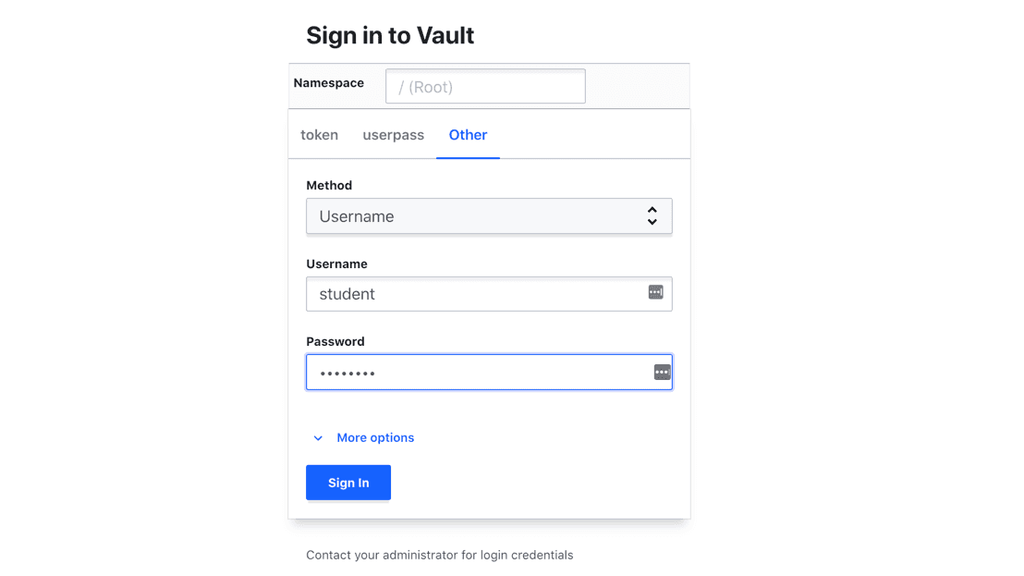

16. Click the Vault CLI shell icon (`>_`) to open a command shell. Execute

    ```
    vault
    write transform/encode/payments value=1111-2222-3333-4444
    ```

    to verify that the user, `student` can encode a credit card number using the payment role.

[figure not shown]

[figure not shown]

### Verify ephemeral resources

The ephemeral resources will not store anyting in the Terraform state file.

1. Verify that the password was not saved in the Terraform state file.

   ```
   $ cat terraform.tfstate | grep root-user-password
   ```

   ```
   $ cat terraform.tfstate | grep data_json_wo
               "data_json_wo": null,
               "data_json_wo_version": 1,
   ```

## Clean up

When you finish exploring the tutorial, you can undo the configuration made by Terraform.

1. Make sure to set the `VAULT_TOKEN` and `VAULT_ADDR` environment variables.

   ```
   $ echo $VAULT_ADDR; echo $VAULT_TOKEN
   ```

2. Destroy the Vault resources created by Terraform.

   ```
   $ terraform destroy -auto-approve

   ...snip...

3. Remove the Terraform state files.

   ```
   $ rm *.tfstate.*
   ```

4. Unset the `VAULT_TOKEN` and `VAULT_ADDR` environment variables.

   ```
   $ unset VAULT_TOKEN VAULT_ADDR
   ```

5. Stop the Vault dev mode server.

   ```
   $ pkill vault
   ```

Note

To learn more about Terraform, visit Learn Terraform.

## Next steps

Treat your Terraform files like any other code and manage them through a version control system such as GitHub. You may integrate it with your favorite CI/CD tool (Jenkins, Travis CI, Circle CI, etc.), always review and test the configuration.

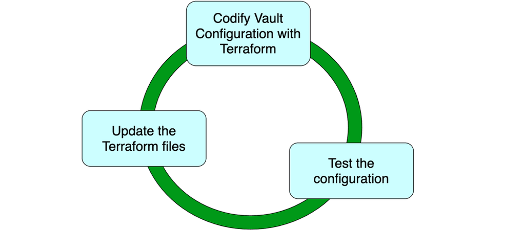

See the [Retrieve CI/CD secrets from Vault](https://developer.hashicorp.com/well-architected-framework/security/security-cicd-vault) for more information on how to integrate Vault with your CI/CD pipeline.

## Summary

In this guide you learned a technique for creating Vault policies and configurations using the Terraform Vault provider. For more information, see the help and reference section.

## Help and reference

- [Terraform Vault provider](https://registry.terraform.io/providers/hashicorp/vault/latest/docs) documentation page
- [Terraform Vault provider GitHub repository](https://github.com/terraform-providers/terraform-provider-vault)
- Learn Terraform
- [Multi-tenancy with Namespaces](https://developer.hashicorp.com/vault/tutorials/cloud/vault-namespaces)

Tip

Terraform users can leverage the Vault's dynamic secrets engine to generate short-live cloud credentials when provisioning cloud resources. Inject secrets into Terraform using the Vault provider tutorial demonstrates the use of AWS secrets engine to manage AWS IAM credentials used by Terraform.

© 2026 HashiCorp  
Licensed under the MPL 2.0 License.  
https://developer.hashicorp.com/terraform/tutorials/security/codify-mgmt-enterprise